# README

CINWPR

CINWPR library is suitable for processing wind profile radar data that meet the common data format V1.2 of the Wind Profile Radar of the China Meteorological Administration(CMA). It currently contains three modules: RWP_READ, RWP_ANALYSIS and RWP_DRAW.

```python
import os
import numpy as np
import xarray as xr
import warnings
import datetime
import matplotlib.pyplot as plt
```

RWP_READ

```python
from CINWPR import RWP_READ
```

The RWP_READ module contains two classes Read_RWP_Data and Read_Muti_RWP_Data, which are suitable for reading single and multiple wind profile radar data respectively.

```python
singal_file=RWP_READ.Read_RWP_Data('Z_RADA_I_58637_20220425000600_O_WPRD_LC_RAD.TXT')
```

Read_RWP_Data

The Read_RWP_Data class contains three functions: Get_data,Get_Radar_RAD_Model_info and Get_Radar_FFT_Model_info, which are used to read the basic data information of the data file respectively. Radar performance parameters and observation parameters in RAD file and FFT file. The class itself also contains some basic site information attributes.

```python
'''
singal_file.lat->浮点类型：站点纬度
singal_file.lon->浮点类型：站点经度
singal_file.height->浮点类型：测站海拔高度
singal_file.time->数据文件时间
singal_file.datatype->文件数据类型
'''
```

```python
singal_file.Get_data(GMT=False)
#GMT参数默认为关闭状态，此时文件时间将为北京时，若将此参数打开将会返回世界时
```

```
<xarray.Dataset>
Dimensions:                    (Level_L: 33, Beam_num_L: 5, Level_M: 32, Beam_num_M: 5)
Coordinates:
  * Level_L                    (Level_L) int64 150 270 390 ... 3750 3870 3990
  * Beam_num_L                 (Beam_num_L) int32 1 2 3 4 5
  * Level_M                    (Level_M) int64 1470 1710 1950 ... 8430 8670 8910
  * Beam_num_M                 (Beam_num_M) int32 1 2 3 4 5
Data variables:
    Velocity_spectrum_width_L  (Beam_num_L, Level_L) float64 0.0 0.0 ... 1.2 0.1
    SNR_L                      (Beam_num_L, Level_L) float64 16.2 20.1 ... 11.8
    Radial_velocity_L          (Beam_num_L, Level_L) float64 -0.1 0.2 ... 1.7
    Velocity_spectrum_width_M  (Beam_num_M, Level_M) float64 0.4 ... -9.999e+03
    SNR_M                      (Beam_num_M, Level_M) float64 19.6 ... -9.999e+03
    Radial_velocity_M          (Beam_num_M, Level_M) float64 -3.0 ... -9.999e+03
Attributes:
    Description:  站号:58637(028.4500,0117.9300)   站点高度:00150.0m    观测时间:2022-0...
```

```python
Rad_Para,Obs_Para=singal_file.Get_Radar_RAD_Model_info(GMT=False)
```

```python
Rad_Para
```

|  | 天线增益 | 馈线损耗 | 东波束-铅垂线夹角 | 西波束-铅垂线夹角 | 南波束-铅垂线夹角 | 北波束-铅垂线夹角 | 中波束(行)-铅垂线夹角 | 中波束(列)-铅垂线夹角 | 波束数 | 采样频率 | 发射波长 | 脉冲重复频率 | 脉冲宽度 | 水平波束宽度 | 垂直波束宽度 | 发射峰值功率 | 发射平均功率 | 起始采样高度 | 终止采样高度 |
| --- | --- | --- | --- | --- | --- | --- | --- | --- | --- | --- | --- | --- | --- | --- | --- | --- | --- | --- | --- |
| Low | 33 | 3.5 | 16.4 | 16.4 | 16.4 | 16.4 | 0.0 | 0.0 | 5 | 0 | 232 | 27777 | 0.8 | 3 | 3 | 2.0 | 0.1 | 150 | 3990 |
| Medium | 33 | 3.5 | 16.4 | 16.4 | 16.4 | 16.4 | 0.0 | 0.0 | 5 | 0 | 232 | 10416 | 6.4 | 3 | 3 | 2.0 | 0.1 | 1470 | 8910 |

```python
Obs_Para
```

|  | 时间来源 | 观测开始时间 | 观测结束时间 | 标校状态 | 非相干积累 | 相干积累 | Fft点数 | 谱平均数 | 波束顺序标志 | 东波束方位角修正值 | 西波束方位角修正值 | 南波束方位角修正值 | 北波束方位角修正值 |
| --- | --- | --- | --- | --- | --- | --- | --- | --- | --- | --- | --- | --- | --- |
| Low | 计算机时钟 | 2022-04-25 00:00:00 | 2022-04-25 00:06:00 | 自动标校 | 24.0 | 100.0 | 256.0 | 24.0 | ENRWS/ | -27.0 | -27.0 | -27.0 | -27.0 |
| Medium | 未知时间来源 | 2022-04-25 00:00:00 | 2022-04-25 00:06:00 | 未知标校 | 26.0 | 40.0 | 256.0 | 26.0 | ENRWS/ | -27.0 | -27.0 | -27.0 | -27.0 |

```python
singal_file=RWP_READ.Read_RWP_Data('Z_RADA_I_58637_20220425000600_P_WPRD_LC_ROBS.TXT')
singal_file.Get_data(GMT=False)
```

```
<xarray.Dataset>
Dimensions:                      (Level: 45)
Coordinates:
  * Level                        (Level) float64 150.0 270.0 ... 8.91e+03
Data variables:
    Wind_direction               (Level) float64 274.0 123.0 ... -9.999e+03
    Horizontal_speed             (Level) float64 1.0 0.9 ... -9.999e+03
    Vertical_speed               (Level) float64 -0.0 0.1 -0.0 ... 0.0 0.0 0.0
    Horizontal_confidence_level  (Level) float64 100.0 100.0 100.0 ... 0.0 0.0
    Vertical_confidence_level    (Level) float64 100.0 100.0 100.0 ... 0.0 0.0
    Vertical_CN2                 (Level) float64 1.2e-18 4.1e-16 ... 2.4e-20
Attributes:
    Description:  站号:58637(028.4500,0117.9300)   站点高度:00150.0m    观测时间:2022-0...
```

```python
singal_file=RWP_READ.Read_RWP_Data('Z_RADA_I_58637_20220425000600_O_WPRD_LC_FFT.BIN')
singal_file.Get_data(GMT=False)
```

```
<xarray.Dataset>
Dimensions:      (Beam_Num_L: 5, Level_L: 33, FFT_Point_L: 256, Beam_Num_M: 5, Level_M: 32, FFT_Point_M: 256)
Coordinates:
  * Beam_Num_L   (Beam_Num_L) int64 1 2 3 4 5
  * Level_L      (Level_L) int64 150 270 390 510 630 ... 3630 3750 3870 3990
  * FFT_Point_L  (FFT_Point_L) float64 1.0 2.0 3.0 4.0 ... 254.0 255.0 256.0
  * Beam_Num_M   (Beam_Num_M) int64 1 2 3 4 5
  * Level_M      (Level_M) int64 1470 1710 1950 2190 ... 8190 8430 8670 8910
  * FFT_Point_M  (FFT_Point_M) float64 1.0 2.0 3.0 4.0 ... 254.0 255.0 256.0
Data variables:
    FFT_L        (Beam_Num_L, Level_L, FFT_Point_L) float64 0.003602 ... 0.04276
    FFT_M        (Beam_Num_M, Level_M, FFT_Point_M) float64 0.6714 ... 0.8502
Attributes:
    Description:  站号:58637(28.45,117.93)   站点高度:150.0m    观测时间:2022-04-25 00:...
```

```python
Rad_Para,Obs_Para=singal_file.Get_Radar_FFT_Model_info(GMT=False)
```

```python
Rad_Para
```

|  | 天线增益 | 馈线损耗 | 东波束-铅垂线夹角 | 西波束-铅垂线夹角 | 南波束-铅垂线夹角 | 北波束-铅垂线夹角 | 中波束(行)-铅垂线夹角 | 中波束(列)-铅垂线夹角 | 扫描波束数 | 采样频率 | ... | 脉冲重复频率 | 脉冲宽度 | 水平波束宽度 | 垂直波束宽度 | 发射峰值功率 | 发射平均功率 | 起始采样高度 | 终止采样高度 | 距离库长 | 距离库数 |
| --- | --- | --- | --- | --- | --- | --- | --- | --- | --- | --- | --- | --- | --- | --- | --- | --- | --- | --- | --- | --- | --- |
| Low | 33 | 3.5 | 16.419998 | 16.419998 | 16.419998 | 16.419998 | 0.0 | 0.0 | 5 | 0 | ... | 27777.777344 | 0.8 | 3 | 3 | 1.995262 | 0.050119 | 150 | 3990 | 120 | 33 |
| Medium | 33 | 3.5 | 16.419998 | 16.419998 | 16.419998 | 16.419998 | 0.0 | 0.0 | 5 | 0 | ... | 10416.666992 | 6.4 | 3 | 3 | 1.995262 | 0.125893 | 1470 | 8910 | 240 | 32 |

2 rows × 21 columns

```python
Obs_Para
```

|  | 观测开始时间 | 时间来源 | 标校状态 | 波束方向改变 | 观测结束时间 | 非相干累计 | 相干累计 | Fft点数 | 谱平均数 | 波束顺序标志 | 有效波束 | 东波束方位角修正值 | 西波束方位角修正值 | 南波束方位角修正值 | 北波束方位角修正值 |
| --- | --- | --- | --- | --- | --- | --- | --- | --- | --- | --- | --- | --- | --- | --- | --- |
| Low | 2022-04-25 00:00:00 | 计算机时钟 | 自动标校 | 0.0 | 2022-04-25 00:06:00 | 24.0 | 100.0 | 256.0 | 24.0 | ENRWS/ | 5 | -27.0 | -27.0 | -27.0 | -27.0 |
| Medium | 2022-04-25 00:00:00 | 计算机时钟 | 自动标校 | 1.0 | 2022-04-25 00:06:00 | 26.0 | 40.0 | 256.0 | 26.0 | ENRWS/ | 5 | -27.0 | -27.0 | -27.0 | -27.0 |

Read_Muti_RWP_Data

```python
filelist[40:50]
```

```
['Z_RADA_I_54399_20190910030244_O_WPRD_LC_RAD.TXT',
 'Z_RADA_I_54399_20190910030712_O_WPRD_LC_RAD.TXT',
 'Z_RADA_I_54399_20190910031143_O_WPRD_LC_RAD.TXT',
 'Z_RADA_I_54399_20190910031609_O_WPRD_LC_RAD.TXT',
 'Z_RADA_I_54399_20190910032039_O_WPRD_LC_RAD.TXT',
 'Z_RADA_I_54399_20190910032509_O_WPRD_LC_RAD.TXT',
 'Z_RADA_I_54399_20190910032939_O_WPRD_LC_RAD.TXT',
 'Z_RADA_I_54399_20190910033410_O_WPRD_LC_RAD.TXT',
 'Z_RADA_I_54399_20190910033840_O_WPRD_LC_RAD.TXT',
 'Z_RADA_I_54399_20190910034310_O_WPRD_LC_RAD.TXT']
```

```python
list_file=RWP_READ.Read_Muti_RWP_Data(filelist[40:50])
```

The RWP_READ.Read_Muti_RWP_Data class contains only the Get_Muti_Data function and some basic data information.

```python
'''
list_file.lat->浮点类型：站点纬度
list_file.lon->浮点类型：站点经度
list_file.height->浮点类型：测站海拔高度
list_file.start_time->数据文件开始时间
list_file.end_time->数据文件结束时间
list_file.datatype->文件数据类型
list_file.state->多文件实时间均一性参量，若为1表示为非均匀数据，0表示为均匀数据
'''
```

```python
list_file.Get_Muti_Data()
```

```
<xarray.Dataset>
Dimensions:                    (Time: 10, Level_L: 30, Beam_num_L: 5, Level_M: 30, Beam_num_M: 5, Level_H: 30, Beam_num_H: 5)
Coordinates:
  * Time                       (Time) float64 0.0 268.0 ... 2.156e+03 2.426e+03
  * Level_L                    (Level_L) int64 150 270 390 ... 3390 3510 3630
  * Beam_num_L                 (Beam_num_L) int32 1 2 3 4 5
  * Level_M                    (Level_M) int64 1110 1230 1350 ... 4350 4470 4590
  * Beam_num_M                 (Beam_num_M) int32 1 2 3 4 5
  * Level_H                    (Level_H) int64 3150 3390 3630 ... 9870 10110
  * Beam_num_H                 (Beam_num_H) int32 1 2 3 4 5
Data variables:
    Ori_Time                   (Time) <U19 '2019-09-10 03:02:44' ... '2019-09...
    SNR_H                      (Time, Beam_num_H, Level_H) float64 13.5 ... 2.4
    Velocity_spectrum_width_M  (Time, Beam_num_M, Level_M) float64 2.0 ... 1.7
    Velocity_spectrum_width_H  (Time, Beam_num_H, Level_H) float64 1.7 ... 0.4
    SNR_M                      (Time, Beam_num_M, Level_M) float64 17.5 ... 9.8
    Radial_velocity_M          (Time, Beam_num_M, Level_M) float64 3.8 ... 1.8
    Velocity_spectrum_width_L  (Time, Beam_num_L, Level_L) float64 2.6 ... 3.0
    SNR_L                      (Time, Beam_num_L, Level_L) float64 20.8 ... 11.0
    Radial_velocity_H          (Time, Beam_num_H, Level_H) float64 2.6 ... -0.0
    Radial_velocity_L          (Time, Beam_num_L, Level_L) float64 3.3 ... 4.2
Attributes:
    Description:  站号:54399(039.9869,0116.2903)   站点高度:00046.9m    观测时间:2019-0...
    Start Time:   2019-09-10 03:02:44
    End Time:     2019-09-10 03:43:10
    State:        Inhomogeneous
```

```python
filelist[-10:]
```

```
['Z_RADA_I_58135_20220720230000_P_WPRD_LC_ROBS.TXT',
 'Z_RADA_I_58135_20220720230600_P_WPRD_LC_ROBS.TXT',
 'Z_RADA_I_58135_20220720231200_P_WPRD_LC_ROBS.TXT',
 'Z_RADA_I_58135_20220720231800_P_WPRD_LC_ROBS.TXT',
 'Z_RADA_I_58135_20220720232400_P_WPRD_LC_ROBS.TXT',
 'Z_RADA_I_58135_20220720233000_P_WPRD_LC_ROBS.TXT',
 'Z_RADA_I_58135_20220720233600_P_WPRD_LC_ROBS.TXT',
 'Z_RADA_I_58135_20220720234200_P_WPRD_LC_ROBS.TXT',
 'Z_RADA_I_58135_20220720234800_P_WPRD_LC_ROBS.TXT',
 'Z_RADA_I_58135_20220720235400_P_WPRD_LC_ROBS.TXT']
```

```python
list_file.Get_Muti_Data()
```

[output not shown]

```python
filelist[-10:]
```

```
['Z_RADA_I_58637_20220425230600_O_WPRD_LC_FFT.BIN',
 'Z_RADA_I_58637_20220425231200_O_WPRD_LC_FFT.BIN',
 'Z_RADA_I_58637_20220425231800_O_WPRD_LC_FFT.BIN',
 'Z_RADA_I_58637_20220425232400_O_WPRD_LC_FFT.BIN',
 'Z_RADA_I_58637_20220425233000_O_WPRD_LC_FFT.BIN',
 'Z_RADA_I_58637_20220425233600_O_WPRD_LC_FFT.BIN',
 'Z_RADA_I_58637_20220425234200_O_WPRD_LC_FFT.BIN',
 'Z_RADA_I_58637_20220425234800_O_WPRD_LC_FFT.BIN',
 'Z_RADA_I_58637_20220425235400_O_WPRD_LC_FFT.BIN',
 'Z_RADA_I_58637_20220426000000_O_WPRD_LC_FFT.BIN']
```

```python
list_file=RWP_READ.Read_Muti_RWP_Data(filelist[-10:])
list_file.Get_Muti_Data()
```

```
<xarray.Dataset>
Dimensions:      (Time: 10, Beam_Num_L: 5, Level_L: 33, FFT_Point_L: 256, Beam_Num_M: 5, Level_M: 32, FFT_Point_M: 256)
Coordinates:
  * Time         (Time) float64 0.0 360.0 720.0 ... 2.52e+03 2.88e+03 3.24e+03
  * Beam_Num_L   (Beam_Num_L) int64 1 2 3 4 5
  * Level_L      (Level_L) int64 150 270 390 510 630 ... 3630 3750 3870 3990
  * FFT_Point_L  (FFT_Point_L) float64 1.0 2.0 3.0 4.0 ... 254.0 255.0 256.0
  * Beam_Num_M   (Beam_Num_M) int64 1 2 3 4 5
  * Level_M      (Level_M) int64 1470 1710 1950 2190 ... 8190 8430 8670 8910
  * FFT_Point_M  (FFT_Point_M) float64 1.0 2.0 3.0 4.0 ... 254.0 255.0 256.0
Data variables:
    Ori_Time     (Time) <U19 '2022-04-25 23:06:00' ... '2022-04-26 00:00:00'
    FFT_M        (Time, Beam_Num_M, Level_M, FFT_Point_M) float64 0.7055 ... ...
    FFT_L        (Time, Beam_Num_L, Level_L, FFT_Point_L) float64 0.004732 .....
Attributes:
    Description:  站号:58637(28.45,117.93)   站点高度:150.0m    观测时间:2022-04-25 23:...
    Start Time:   2022-04-25 23:06:00
    End Time:     2022-04-26 00:00:00
    State:        Inhomogeneous
```

RWP_ANALYSIS

The RWP_ANALYSIS module contains two classes Get_Product and Get_Muti_Product, which are suitable for analyzing and processing single wind profile radar data and multiple wind profile radar data respectively.

```python
from CINWPR import RWP_ANALYSIS
```

```python
import os
os.chdir(r'D:\54399')
```

```python
import numpy as np
```

```python
filelist=os.listdir()
```

```python
wind,spect,eddy=RWP_ANALYSIS.Get_Product('Z_RADA_I_54399_20190910030244_O_WPRD_LC_RAD.TXT').Get_RAD_Product()
```

```python
wind
```

```
<xarray.Dataset>
Dimensions:           (Level_L: 30, Level_M: 30, Level_H: 30)
Coordinates:
  * Level_L           (Level_L) int64 150 270 390 510 ... 3270 3390 3510 3630
  * Level_M           (Level_M) int64 1110 1230 1350 1470 ... 4350 4470 4590
  * Level_H           (Level_H) int64 3150 3390 3630 3870 ... 9630 9870 10110
Data variables: (12/15)
    Wind_Shear_L      (Level_L) float64 -0.009388 -0.001995 ... 0.008614 -999.0
    U_L               (Level_L) float64 -11.82 -12.41 -12.99 ... -10.7 -10.11
    V_L               (Level_L) float64 -12.43 -13.42 -13.2 ... -5.396 -4.198
    W_L               (Level_L) float64 3.3 3.5 3.7 3.9 4.1 ... 2.7 2.6 2.5 2.3
    Wind_Direction_L  (Level_L) float64 223.6 222.7 224.6 ... 240.5 243.2 247.4
    Wind_Shear_M      (Level_M) float64 0.0245 -0.0141 ... -0.01116 -999.0
    ...                ...
    Wind_Direction_M  (Level_M) float64 221.6 222.3 222.5 ... 105.9 117.3 121.6
    Wind_Shear_H      (Level_H) float64 0.003653 0.002691 ... -147.9 -999.0
    U_H               (Level_H) float64 -11.91 -11.51 ... 3.949e+04 -31.51
    V_H               (Level_H) float64 -8.033 -7.026 ... 3.951e+04 2.037e+04
    W_H               (Level_H) float64 2.6 2.5 2.4 2.2 ... 1.2 -9.999e+03 2.3
    Wind_Direction_H  (Level_H) float64 236.0 238.6 240.0 ... 256.3 225.0 179.9
Attributes:
    Description:  站号:54399(039.9869,0116.2903)   站点高度:00046.9m    观测时间:2019-0...
```

```python
spect
```

```
<xarray.Dataset>
Dimensions:                    (Level_L: 30, Beam_num_L: 5, Level_M: 30, Beam_num_M: 5, Level_H: 30, Beam_num_H: 5)
Coordinates:
  * Level_L                    (Level_L) int64 150 270 390 ... 3390 3510 3630
  * Beam_num_L                 (Beam_num_L) int32 1 2 3 4 5
  * Level_M                    (Level_M) int64 1110 1230 1350 ... 4350 4470 4590
  * Beam_num_M                 (Beam_num_M) int32 1 2 3 4 5
  * Level_H                    (Level_H) int64 3150 3390 3630 ... 9870 10110
  * Beam_num_H                 (Beam_num_H) int32 1 2 3 4 5
Data variables: (12/15)
    Doppler_spectral_width_L   (Beam_num_L, Level_L) float64 6.76 4.84 ... 2.25
    Beam_broadening_L          (Beam_num_L, Level_L) float64 0.07953 ... 0.04937
    Shear_broadening_L         (Beam_num_L, Level_L) float64 0.01 ... -999.0
    Turbulent_spectra_width_L  (Beam_num_L, Level_L) float64 6.179 ... -999.0
    Resodia_Noise_L            (Beam_num_L) float64 0.2207 0.07627 ... 0.04406
    Doppler_spectral_width_M   (Beam_num_M, Level_M) float64 4.0 12.96 ... 2.89
    ...                         ...
    Resodia_Noise_M            (Beam_num_M) float64 0.2958 0.1101 ... 0.09822
    Doppler_spectral_width_H   (Beam_num_H, Level_H) float64 2.89 2.56 ... 0.81
    Beam_broadening_H          (Beam_num_H, Level_H) float64 0.04937 ... 0.8361
    Shear_broadening_H         (Beam_num_H, Level_H) float64 0.16 ... -999.0
    Turbulent_spectra_width_H  (Beam_num_H, Level_H) float64 2.144 ... -999.0
    Resodia_Noise_H            (Beam_num_H) float64 0.4207 0.2827 ... 0.3265
Attributes:
    Description:  站号:54399(039.9869,0116.2903)   站点高度:00046.9m    观测时间:2019-0...
```

```python
eddy
```

```
<xarray.Dataset>
Dimensions:                      (Level_L: 30, Beam_num_L: 5, Level_M: 30, Beam_num_M: 5, Level_H: 30, Beam_num_H: 5)
Coordinates:
  * Level_L                      (Level_L) int64 150 270 390 ... 3390 3510 3630
  * Beam_num_L                   (Beam_num_L) int32 1 2 3 4 5
  * Level_M                      (Level_M) int64 1110 1230 1350 ... 4470 4590
  * Beam_num_M                   (Beam_num_M) int32 1 2 3 4 5
  * Level_H                      (Level_H) int64 3150 3390 3630 ... 9870 10110
  * Beam_num_H                   (Beam_num_H) int32 1 2 3 4 5
Data variables:
    Eddy_dissipation_rate_L      (Beam_num_L, Level_L) float64 0.00401 ... -9...
    Brunt_Vaisala_frequency_L    (Beam_num_L, Level_L) float64 0.001081 ... -...
    Vertical_eddy_diffusivity_L  (Beam_num_L, Level_L) float64 1.143e+03 ... ...
    Eddy_dissipation_rate_M      (Beam_num_M, Level_M) float64 nan ... -999.0
    Brunt_Vaisala_frequency_M    (Beam_num_M, Level_M) float64 nan ... -999.0
    Vertical_eddy_diffusivity_M  (Beam_num_M, Level_M) float64 nan ... -999.0
    Eddy_dissipation_rate_H      (Beam_num_H, Level_H) float64 0.0002405 ... ...
    Brunt_Vaisala_frequency_H    (Beam_num_H, Level_H) float64 0.0001869 ... ...
    Vertical_eddy_diffusivity_H  (Beam_num_H, Level_H) float64 2.295e+03 ... ...
Attributes:
    Description:  站号:54399(039.9869,0116.2903)   站点高度:00046.9m    观测时间:2019-0...
```

```python
filelist[:5]
```

```
['Z_RADA_I_54399_20190910000300_O_WPRD_LC_RAD.TXT',
 'Z_RADA_I_54399_20190910000728_O_WPRD_LC_RAD.TXT',
 'Z_RADA_I_54399_20190910001158_O_WPRD_LC_RAD.TXT',
 'Z_RADA_I_54399_20190910001629_O_WPRD_LC_RAD.TXT',
 'Z_RADA_I_54399_20190910002058_O_WPRD_LC_RAD.TXT']
```

```python
Wind_Data_Structure,Spectral_Data_Structure,Eddy_Data_Structure=RWP_ANALYSIS.Get_Muti_Product(filelist[:5]).Get_Muti_Product_Data()
```

```python
Wind_Data_Structure
```

```
<xarray.Dataset>
Dimensions:           (Time: 5, Level_L: 30, Level_M: 30, Level_H: 30)
Coordinates:
  * Time              (Time) float64 0.0 268.0 538.0 809.0 1.078e+03
  * Level_L           (Level_L) int64 150 270 390 510 ... 3270 3390 3510 3630
  * Level_M           (Level_M) int64 1110 1230 1350 1470 ... 4350 4470 4590
  * Level_H           (Level_H) int64 3150 3390 3630 3870 ... 9630 9870 10110
Data variables: (12/16)
    Ori_Time          (Time) <U19 '2019-09-10 00:03:00' ... '2019-09-10 00:20...
    Wind_Direction_H  (Time, Level_H) float64 94.1 252.2 267.5 ... 270.0 270.0
    W_L               (Time, Level_L) float64 0.8 -0.0 0.0 3.2 ... 3.0 1.8 1.4
    U_L               (Time, Level_L) float64 6.418 9.58 9.376 ... -15.47 -12.46
    Wind_Direction_M  (Time, Level_M) float64 195.1 196.8 197.9 ... 250.3 245.1
    V_L               (Time, Level_L) float64 -3.977 5.299 ... -1.814 -0.02945
    ...                ...
    Wind_Direction_L  (Time, Level_L) float64 121.8 241.0 241.5 ... 263.3 269.9
    U_H               (Time, Level_H) float64 -10.27 -12.02 ... -2.039e+04
    V_H               (Time, Level_H) float64 0.736 -3.865 ... -8.22 -3.286
    Wind_Shear_L      (Time, Level_L) float64 0.1542 -0.002306 ... -999.0
    W_M               (Time, Level_M) float64 3.5 3.2 3.2 3.2 ... 1.1 1.0 1.0
    Wind_Shear_H      (Time, Level_H) float64 -0.0955 0.008169 ... -999.0
Attributes:
    Description:  站号:54399(039.9869,0116.2903)   站点高度:00046.9m    观测时间:2019-0...
    Start Time:   2019-09-10 00:03:00
    End Time:     2019-09-10 00:20:58
    State:        Inhomogeneous
```

```python
Spectral_Data_Structure
```

```
<xarray.Dataset>
Dimensions:                    (Time: 5, Level_L: 30, Beam_num_L: 5, Level_M: 30, Beam_num_M: 5, Level_H: 30, Beam_num_H: 5)
Coordinates:
  * Time                       (Time) float64 0.0 268.0 538.0 809.0 1.078e+03
  * Level_L                    (Level_L) int64 150 270 390 ... 3390 3510 3630
  * Beam_num_L                 (Beam_num_L) int32 1 2 3 4 5
  * Level_M                    (Level_M) int64 1110 1230 1350 ... 4350 4470 4590
  * Beam_num_M                 (Beam_num_M) int32 1 2 3 4 5
  * Level_H                    (Level_H) int64 3150 3390 3630 ... 9870 10110
  * Beam_num_H                 (Beam_num_H) int32 1 2 3 4 5
Data variables: (12/16)
    Ori_Time                   (Time) <U19 '2019-09-10 00:03:00' ... '2019-09...
    Resodia_Noise_M            (Time, Beam_num_M) float64 0.4198 ... 0.4963
    Turbulent_spectra_width_L  (Time, Beam_num_L, Level_L) float64 7.994 ... ...
    Shear_broadening_L         (Time, Beam_num_L, Level_L) float64 0.16 ... -...
    Resodia_Noise_H            (Time, Beam_num_H) float64 0.2827 ... 0.9093
    Beam_broadening_M          (Time, Beam_num_M, Level_M) float64 0.08946 .....
    ...                         ...
    Beam_broadening_L          (Time, Beam_num_L, Level_L) float64 0.004674 ....
    Shear_broadening_H         (Time, Beam_num_H, Level_H) float64 7.84 ... -...
    Turbulent_spectra_width_M  (Time, Beam_num_M, Level_M) float64 1.891 ... ...
    Resodia_Noise_L            (Time, Beam_num_L) float64 0.481 0.498 ... 0.5493
    Beam_broadening_H          (Time, Beam_num_H, Level_H) float64 0.007303 ....
    Doppler_spectral_width_L   (Time, Beam_num_L, Level_L) float64 9.0 ... 6.76
Attributes:
    Description:  站号:54399(039.9869,0116.2903)   站点高度:00046.9m    观测时间:2019-0...
    Start Time:   2019-09-10 00:03:00
    End Time:     2019-09-10 00:20:58
    State:        Inhomogeneous
```

```python
Eddy_Data_Structure
```

```
<xarray.Dataset>
Dimensions:                      (Time: 5, Level_L: 30, Beam_num_L: 5, Level_M: 30, Beam_num_M: 5, Level_H: 30, Beam_num_H: 5)
Coordinates:
  * Time                         (Time) float64 0.0 268.0 538.0 809.0 1.078e+03
  * Level_L                      (Level_L) int64 150 270 390 ... 3390 3510 3630
  * Beam_num_L                   (Beam_num_L) int32 1 2 3 4 5
  * Level_M                      (Level_M) int64 1110 1230 1350 ... 4470 4590
  * Beam_num_M                   (Beam_num_M) int32 1 2 3 4 5
  * Level_H                      (Level_H) int64 3150 3390 3630 ... 9870 10110
  * Beam_num_H                   (Beam_num_H) int32 1 2 3 4 5
Data variables:
    Ori_Time                     (Time) <U19 '2019-09-10 00:03:00' ... '2019-...
    Eddy_dissipation_rate_L      (Time, Beam_num_L, Level_L) float64 0.01452 ...
    Vertical_eddy_diffusivity_L  (Time, Beam_num_L, Level_L) float64 528.0 .....
    Eddy_dissipation_rate_H      (Time, Beam_num_H, Level_H) float64 nan ... ...
    Brunt_Vaisala_frequency_M    (Time, Beam_num_M, Level_M) float64 0.000374...
    Vertical_eddy_diffusivity_M  (Time, Beam_num_M, Level_M) float64 1.011e+0...
    Brunt_Vaisala_frequency_L    (Time, Beam_num_L, Level_L) float64 0.003028...
    Eddy_dissipation_rate_M      (Time, Beam_num_M, Level_M) float64 0.000424...
    Brunt_Vaisala_frequency_H    (Time, Beam_num_H, Level_H) float64 nan ... ...
    Vertical_eddy_diffusivity_H  (Time, Beam_num_H, Level_H) float64 nan ... ...
Attributes:
    Description:  站号:54399(039.9869,0116.2903)   站点高度:00046.9m    观测时间:2019-0...
    Start Time:   2019-09-10 00:03:00
    End Time:     2019-09-10 00:20:58
    State:        Inhomogeneous
```

RWP_DRAW

```python
from CINWPR import RWP_DRAW
```

At present, this module only contains this unique function draw_time_height_section, to be used to automatically give the data time-height profile information, the following is the main parameters of this function, the rest parameters see the file source code.

```python
'''
ax为画图画布;
time_list为时间轴，应为datatime形式的列表数据;
height_arr为高度轴：应为numpy.array形式数据;
draw_data为所需绘制的数据，应为numpy.array形式;
draw_levels为绘制的数据的levels数组;
colorbar_ticks为colorbar标签说明;
time_interval为时间ticks间隔，以秒计算
height_interval为高度间隔，以米(m)为单位，根据国内常见风廓线雷达的垂直高度分辨率推荐尝试600及其倍数
data_declaration为填色数据说明，用于colorbar说明，格式为：'数据名称(数据单位)';
color为填图颜色默认为：cmaps.BlAqGrYeOrReVi;
timelabel为时间轴说明标签，默认为当地标准时间(LST);
beam_direction为波束方向说明;
'''
```

```python
Spect_Data_Structure=xr.open_dataset('D:/Qingdao_Spect_20220901.nc')
```

```python
Spect_Data_Structure
```

```
<xarray.Dataset>
Dimensions:                    (Time: 283, Level_L: 20, Beam_num_L: 5, Level_M: 98, Beam_num_M: 5)
Coordinates:
  * Time                       (Time) float64 0.0 300.0 ... 8.58e+04 8.61e+04
  * Level_L                    (Level_L) int64 120 240 360 ... 2160 2280 2400
  * Beam_num_L                 (Beam_num_L) int32 1 2 3 4 5
  * Level_M                    (Level_M) int64 240 480 720 ... 23040 23280 23520
  * Beam_num_M                 (Beam_num_M) int32 1 2 3 4 5
Data variables:
    Ori_Time                   (Time) object '2022-09-01 00:00:07' ... '2022-...
    Shear_broadening_L         (Time, Beam_num_L, Level_L) float64 0.0025 ......
    Resodia_Noise_L            (Time, Beam_num_L) float64 0.053 ... 0.02128
    Turbulent_spectra_width_L  (Time, Beam_num_L, Level_L) float64 0.5589 ......
    Turbulent_spectra_width_M  (Time, Beam_num_M, Level_M) float64 ...
    Resodia_Noise_M            (Time, Beam_num_M) float64 0.01141 ... 0.04973
    Doppler_spectral_width_M   (Time, Beam_num_M, Level_M) float64 ...
    Beam_broadening_M          (Time, Beam_num_M, Level_M) float64 ...
    Beam_broadening_L          (Time, Beam_num_L, Level_L) float64 0.0 ... 0....
    Doppler_spectral_width_L   (Time, Beam_num_L, Level_L) float64 0.64 ... 0.49
    Shear_broadening_M         (Time, Beam_num_M, Level_M) float64 ...
Attributes:
    Description:  站号:54857(036.2283,0120.1250)   站点高度:00012.0m    观测时间:2022-0...
    Start Time:   2022-09-01 00:00:07
    End Time:     2022-09-01 23:55:07
    State:        Inhomogeneous
```

```python
heights=np.array(Spect_Data_Structure['Level_L'[:]])
```

```python
standard_formaet='%Y-%m-%d %H:%M:%S'
time_format_list=[]
for ori_time_str in list(np.array(Spect_Data_Structure['Ori_Time'][:])):
    time_format_list.append(datetime.datetime.strptime(ori_time_str,standard_formaet))
```

```python
data_declaration=r'$\sigma$$^2$$_{obs}$'+'(m$^2$·s$^{-2}$)'
```

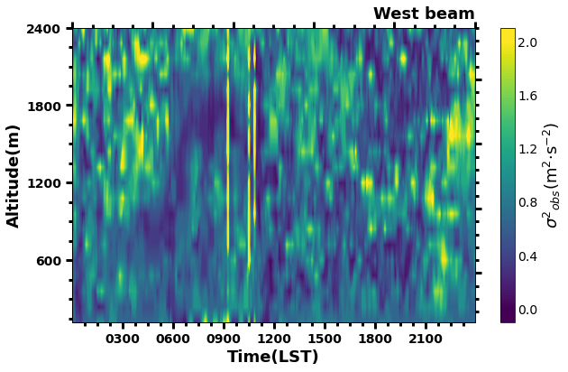

```python
fig,ax1=plt.subplots(figsize=(10,6),nrows=1,ncols=1)
plt.subplots_adjust(wspace=0.2,hspace=0.15)
ax1.spines['top'].set_visible(False)
ax1.spines['right'].set_visible(False)


RWP_DRAW.draw_time_height_section(ax=ax1,time_list=time_format_list,height_arr=heights,draw_data=np.array(Spect_Data_Structure['Doppler_spectral_width_L'][:,0,:]).T,draw_levels=np.arange(0,2.002,0.02),colorbar_ticks=np.arange(0,2.1,0.4),data_declaration=data_declaration,beam_direction='West beam',beam_pad=10)
```